# chapter3

### 8. **Super-Bonus:** cross-validation to different model **(0-4 points)**

- Perform cross-validation to compare the performance of different logistic regression models (= different sets of predictors).
- Start with a very high number of predictors and explore the changes in the training and testing errors as you move to models with less predictors.
- Draw a graph displaying the trends of both training and testing errors by the number of predictors in the model.
  - **Comment added later**: x-axis should have number of variables used, y-axis two lines (trainig and testing error)

**Variables:**

- Dependent = **high_use** (alcohol consumption incl. both weekend/weekdays is higher than 2)

**Individual predictors (model_a):**

- **sex** (binary: (F) female or (M) male)
- **age** student’s age (numeric: from 15 to 22)

**Family predictors (model_b):**

- **Pstatus** parent’s cohabitation status (T) living together or (A) apart
- **Medu** mother’s education (numeric: 0 none, 1 primary education, 2, 3 or 4 higher education)
- **Fedu** father’s education (numeric: 0 none, 1 primary education, 2, 3 or 4 higher education)
- **famsup** family educational support (binary: yes or no)

**Relationship predictors (model_c):**

- **romatic** with a romantic relationship (binary: yes or no)
- **famrel** quality of family relationships (numeric: from 1 - very bad to 5 - excellent)
- **goout** going out with friends; numeric: from 1 - very low to 5 - very high

```r
m_e1 <- glm(high_use ~ sex + age + Pstatus + Medu + Fedu + famsup + romantic + famrel + goout, data = alc_a3, family = "binomial") # glm()
summary(m_e1) # you can also get the whole summary of the model using summary()-command
```

```
##
## Call:
## glm(formula = high_use ~ sex + age + Pstatus + Medu + Fedu +
##     famsup + romantic + famrel + goout, family = "binomial",
##     data = alc_a3)
##
## Deviance Residuals:
##     Min       1Q   Median       3Q      Max
## -1.5034  -0.7839  -0.5248   0.8328   2.7038
##
## Coefficients:
##             Estimate Std. Error z value Pr(>|z|)
## (Intercept) -4.08144    1.99332  -2.048  0.04060 *
## sexM         1.00902    0.26233   3.846  0.00012 ***
## age          0.13919    0.11148   1.249  0.21181
## PstatusT    -0.16469    0.41922  -0.393  0.69444
## Medu        -0.13851    0.15388  -0.900  0.36806
## Fedu         0.06658    0.15400   0.432  0.66551
## famsupyes    0.02742    0.27038   0.101  0.91923
## romanticyes -0.26041    0.27990  -0.930  0.35218
## famrel      -0.45258    0.14096  -3.211  0.00132 **
## goout        0.78842    0.12423   6.347  2.2e-10 ***
## ---
## Signif. codes:  0 '***' 0.001 '**' 0.01 '*' 0.05 '.' 0.1 ' ' 1
##
## (Dispersion parameter for binomial family taken to be 1)
##
##     Null deviance: 452.04  on 369  degrees of freedom
## Residual deviance: 375.84  on 360  degrees of freedom
## AIC: 395.84
##
## Number of Fisher Scoring iterations: 4
```

```r
m_e2 <- glm(high_use ~ Pstatus + Medu + Fedu + famsup + romantic + famrel + goout, data = alc_a3, family = "binomial") # glm()
summary(m_e2) # you can also get the whole summary of the model using summary()-command
```

```
##
## Call:
## glm(formula = high_use ~ Pstatus + Medu + Fedu + famsup + romantic +
##     famrel + goout, family = "binomial", data = alc_a3)
##
## Deviance Residuals:
##     Min       1Q   Median       3Q      Max
## -1.7118  -0.7869  -0.5605   0.9787   2.4585
##
## Coefficients:
##             Estimate Std. Error z value Pr(>|z|)
## (Intercept) -1.50647    0.80400  -1.874  0.06097 .
## PstatusT    -0.11758    0.40944  -0.287  0.77398
## Medu        -0.10248    0.14972  -0.684  0.49368
## Fedu         0.05997    0.14909   0.402  0.68750
## famsupyes   -0.17237    0.25814  -0.668  0.50430
## romanticyes -0.25006    0.26880  -0.930  0.35222
## famrel      -0.39998    0.13538  -2.954  0.00313 **
## goout        0.80180    0.12025   6.668 2.59e-11 ***
## ---
## Signif. codes:  0 '***' 0.001 '**' 0.01 '*' 0.05 '.' 0.1 ' ' 1
##
## (Dispersion parameter for binomial family taken to be 1)
##
##     Null deviance: 452.04  on 369  degrees of freedom
## Residual deviance: 392.67  on 362  degrees of freedom
## AIC: 408.67
##
## Number of Fisher Scoring iterations: 4
```

```r
m_e3 <- glm(high_use ~ romantic + famrel + goout, data = alc_a3, family = "binomial") # glm()
summary(m_e3) # you can also get the whole summary of the model using summary()-command
```

```
##
## Call:
## glm(formula = high_use ~ romantic + famrel + goout, family = "binomial",
##     data = alc_a3)
##
## Deviance Residuals:
##     Min       1Q   Median       3Q      Max
## -1.5967  -0.7778  -0.5440   0.9544   2.4264
##
## Coefficients:
##             Estimate Std. Error z value Pr(>|z|)
## (Intercept)  -1.8394     0.6253  -2.941  0.00327 **
## romanticyes  -0.2582     0.2684  -0.962  0.33607
## famrel       -0.3969     0.1350  -2.939  0.00329 **
## goout         0.7954     0.1195   6.655 2.83e-11 ***
## ---
## Signif. codes:  0 '***' 0.001 '**' 0.01 '*' 0.05 '.' 0.1 ' ' 1
##
## (Dispersion parameter for binomial family taken to be 1)
##
##     Null deviance: 452.04  on 369  degrees of freedom
## Residual deviance: 393.71  on 366  degrees of freedom
## AIC: 401.71
##
## Number of Fisher Scoring iterations: 4
```

```r
loss_func <- function(class, prob) {
  n_wrong <- abs(class - prob) > 0.5 # loss function (average prediction error) more than 50%
  mean(n_wrong)
}
```

```r
set.seed(2367)
cv_e1_test <- cv.glm(data = alc_a3, cost = loss_func, glmfit = m_e1, K = nrow(alc_a3))
cv_e1_test$delta[1]
```

```
## [1] 0.2324324
```

```r
cv_e1 <- cv.glm(data = alc_a3, cost = loss_func, glmfit = m_e1, K = 10)
cv_e1$delta[1]
```

```
## [1] 0.2351351
```

```r
cv_e2_test <- cv.glm(data = alc_a3, cost = loss_func, glmfit = m_e2, K = nrow(alc_a3))
cv_e2_test$delta[1]
```

```
## [1] 0.2594595
```

```r
cv_e2 <- cv.glm(data = alc_a3, cost = loss_func, glmfit = m_e2, K = 10)
cv_e2$delta[1]
```

```
## [1] 0.2567568
```

```r
cv_e3_test <- cv.glm(data = alc_a3, cost = loss_func, glmfit = m_e3, nrow(alc_a3))
cv_e3_test$delta[1]
```

```
## [1] 0.2513514
```

```r
cv_e3 <- cv.glm(data = alc_a3, cost = loss_func, glmfit = m_e3, K = 10)
cv_e3$delta[1]
```

```
## [1] 0.2513514
```

set.seed(2367) is a random number that is used each time to generate the cv values. This means we should get the same values everytime now, without it the cv-values differ each time, since it re-generates them each time. We need this since cv.glm() has a random generator build in the function.

```r
e1d_test=cv_e1_test$delta[1]
e1d=cv_e1$delta[1]
e2d_test=cv_e2_test$delta[1]
e2d=cv_e2$delta[1]
e3d_test=cv_e3_test$delta[1]
e3d=cv_e3$delta[1]

deltas_test=c(e1d_test, e2d_test, e3d_test)
deltas_test
```

```
## [1] 0.2324324 0.2594595 0.2513514
```

```r
deltas_train=c(e1d, e2d, e3d)
deltas_train
```

```
## [1] 0.2351351 0.2567568 0.2513514
```

```r
deltas=c(e1d_test, e2d_test, e3d_test,e1d, e2d, e3d)
deltas
```

```
## [1] 0.2324324 0.2594595 0.2513514 0.2351351 0.2567568 0.2513514
```

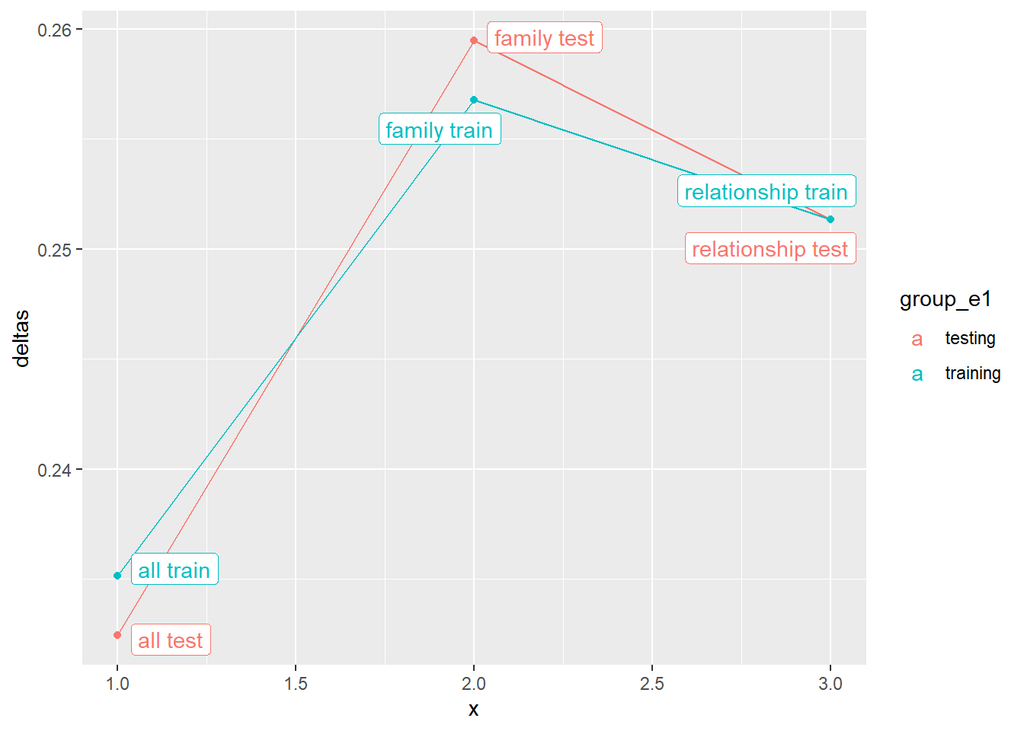

```r
group_e1=c("testing", "testing","testing", "training", "training", "training")

label_names=c("all test", "family test", "relationship test",
              "all train", "family train", "relationship train")

superbonus1 = data.frame(x=c(1:3),
                         deltas,
                         group_e1,
                         label_names)

library(ggrepel)
ggplot(superbonus1, aes(x = x, y = deltas, color = group_e1, group = group_e1)) +
  geom_point() + geom_line() +
   geom_label_repel(aes(label = label_names),
                  box.padding   = 0.35,
                  point.padding = 0.5,
                  segment.color = 'grey50')
```

Unsure if this is the correct one. I found this [link](https://rstudio-pubs-static.s3.amazonaws.com/224739_0b86cafbb6d5421ab92c9dc1dd982690.html) that I found useful.

**NOTE.** $\color{red}{\text{I am not very confident that I got this right, nor I even understood the task correct. I need to go through others assignments and see if I can find solution there.}}$

End of assignment 3.